# Metabolitos de la microbiota fecal en niños con autismo

Isabel-Quirós-Rodríguez-PEC1

06/11/2024

Repositorio en github: https://github.com/IsabelQuiros/Quiros-Rodriguez-Isabel-PEC1.git

## 1 La pregunta biológica

El estudio del que estragimos los datos es ‘Differences in fecal microbial metabolites and microbiota of children with autism spectrum disorders’ de Kang DW et al (2017). En este artículo, los autores se plantean la existencia de diferencias entre los metabolitos del microbioma intestinal de niños con autismo y sin él. Existen numerosos estudios que estudian la composición de la microbiota intestinal entre niños con autismo y niños neurotípicos, pero pocos o ninguno se centran en los metabolitos. Pretenden con esto establecer una relación entre el comportamiento de niños con autismo y la concentración de dichos metabolitos.

## 2 Diseño experimental

Para el diseño experimental se van a emplear 21 niños con ASD y 23 niños neurotípicos, todos entre 4 y 17 años. Para que la microbiota no presente alteraciones, ninguno de los niños ha consumido antibióticos en el mes anterior al estudio. Para la obtención de resultados, el estudio compara la expresión de dichos metabolitos entre ambos grupos. El artículo en cuestión no realiza ninguna modificación ni alteración de los individuos, su finalidad es meramente descriptiva, por lo que el diseño experimental se reduce a la toma de muestras y al estudio comparativo entre los dos grupos de estudio.

## 3 Obtención de los datos crudos.

Para el estudio se tomaron distintas muestras: - Muestras fecales de las cuales se extrageron las concentraciones de los metabolitos. - Extracción de DNA a partir de las muestras fecales para la secuenciación del 16 rRNA e identificación de los diferentes géneros microbianos.

## 4 Análisis estadístico

Como bien indican en el propio estudio, como su muestra es pequeña 21 y 23 niños, emplearon el test no paramétrico de Mann Whitney para testear diferencias en metabolitos y en la abundancia de los taxones microbianos. Emplearon también el Fisher Discriminant Analysis (FDA) para buscar grupos de variables que se pudiesen distinguir entre los niños ASD y el control.

## 5 Respuesta a la pregunta biológica

Los resultados del análisis es la detección de ciertos metabolitos diferencialmente expresados entre los niños con ASD y el control. De la msima forma, ciertos taxones microbianos (aunque no es el dataset que ha sido analizado en esta PEC) presentan también diferencias entre los dos grupos. Estos resultados sirven para concluir la existencia de diferencias tanto en metabolitos como en microorganismos entre los dos grupos. Concluyen diciendo que sería necesario completar los estudios y profundizar más en los resultados con un número de muestras más amplio.

## 6 SumarizedExperiment

Cargamos los datos para hacer el contenedor SummarizedExperiment(). Los datos se descargaron de https://github.com/borenstein-lab/microbiome-metabolome-curated-data/tree/89a519d8c832008fbc6e650453e83e2f04858d02/data/processed_data/KANG_AUTISM_2017

Para poder hacer el Summarized Experiment necesitamos un par de archivos. - Un archivo con los datos de interés. En nuestro caso se trata de un dataframe donde las filas se corresponderán con los distintos casos de estudio (los distintos niños) y las columnas se corresponden con los diferentes metabolitos del estudio. - Un dataframe con la información de las columnas, es decir, qué es cada metabolito, de donde se ha sacado y referencias. - Un último dataframe con la información para las filas, qué es cada paciente (con autismo o sin él), la edad, sexo y demás información que pueda ser de interés.

```r
# Cargamos los df del experimento
df_counts <- read.csv(file="mtb.tsv", row.names = 1, head=TRUE, sep='\t')
df_metadata <- read.csv(file="metadata.tsv", head=TRUE, sep='\t')
df_coldata <- read.csv(file='mtb.map.tsv', head=TRUE, sep='\t')
df_metadata <- read.csv(file='metadata.tsv', head=TRUE, sep='\t')

se <<- SummarizedExperiment(assays=df_counts, rowData=df_metadata, colData=df_coldata)
```

Nuestro objeto se llama ‘se’. Contiene el metadata con la información para las filas (sobre los pacientes) y las columnas (información sobre los metabolitos). Vemos los nombres de las columnas

```r
colnames(se)
```

```
##  [1] "X2.Aminobutyrate"                  "X3.Phenylpropionate"
##  [3] "X4.Aminobutyrate"                  "Acetate"
##  [5] "Alanine"                           "Arginine"
##  [7] "Aspartate"                         "Butyrate"
##  [9] "Caprate"                           "Choline"
## [11] "Ethanol"                           "Formate"
## [13] "Fumarate"                          "Glucose"
## [15] "Glutamate"                         "Glutamine"
## [17] "Glycerol"                          "Glycine"
## [19] "Histidine"                         "Isobutyrate"
## [21] "Isoleucine"                        "Isopropanol"
## [23] "Isovalerate"                       "Lactate"
## [25] "Leucine"                           "Lysine"
## [27] "Malonate"                          "Methanol"
## [29] "Methionine"                        "Methylamine"
```

[output cut: 16 more lines]

Analizamos las dimensiones de nuestro objeto

```r
dim(se)
```

```
## [1] 44 61
```

Vemos que nuestro objeto tiene 44 observaciones y 61 columnas (metabolitos).

Vamos acceder ahora a los nombres de filas y columnas:

```r
head(na.omit(rowData(se)))
```

```
## DataFrame with 6 rows and 38 columns
##              Dataset      Sample     Subject Study.Group       Age   Age.Units
##          <character> <character> <character> <character> <integer> <character>
## A02 KANG_AUTISM_2017         A02         A02   Autistic          4       Years
## A03 KANG_AUTISM_2017         A03         A03   Autistic          9       Years
## A04 KANG_AUTISM_2017         A04         A04   Autistic          9       Years
## A05 KANG_AUTISM_2017         A05         A05   Autistic          6       Years
## A06 KANG_AUTISM_2017         A06         A06   Autistic          9       Years
## A07 KANG_AUTISM_2017         A07         A07   Autistic          7       Years
##          Gender                    DOI       Publication.Name RawSampleID
##     <character>            <character>            <character> <character>
## A02        Male 10.1016/j.anaerobe.2.. Differences in fecal..          A6
## A03        Male 10.1016/j.anaerobe.2.. Differences in fecal..          A7
## A04        Male 10.1016/j.anaerobe.2.. Differences in fecal..          A8
## A05        Male 10.1016/j.anaerobe.2.. Differences in fecal..          A9
## A06        Male 10.1016/j.anaerobe.2.. Differences in fecal..         A10
## A07        Male 10.1016/j.anaerobe.2.. Differences in fecal..         A11
##     BarcodeSequence LinkerPrimerSequence  BarcodeName     Repeats
##         <character>          <character>  <character> <character>
## A02        CATGACGT    GGCGVACGGGTGAGTAA 104Fbarcod10           0
## A03        CCAACGAT    GGCGVACGGGTGAGTAA 104Fbarcod27           0
## A04        CCAACGTA    GGCGVACGGGTGAGTAA 104Fbarcod28           0
## A05        CCAAGCAT    GGCGVACGGGTGAGTAA 104Fbarcod29           0
## A06        CCAAGCTA    GGCGVACGGGTGAGTAA 104Fbarcod30           0
## A07        CCAAGGAA    GGCGVACGGGTGAGTAA 104Fbarcod31           0
##     New_or_Reinvited Constipation_GS_1 Diarrhea_GS_2 Consistency_GS_3
##          <character>         <integer>     <integer>        <integer>
## A02              New                 2             0                0
## A03              New                 0             0                0
## A04              New                 2             1                1
## A05              New                 1             0                0
## A06          Revisit                 1             1                1
## A07          Revisit                 0             0                0
##     Smell_GS_4 Flatulence_GS_5 Abdominal_pain_GS_6 GS_Index_total
##      <integer>       <integer>           <integer>      <integer>
## A02          0               0                   0              2
## A03          0               1                   1              2
## A04          2               2                   1              9
## A05          1               0                   0              2
## A06          2               2                   2              9
```

[output cut: 66 more lines]

```
##                                       <integer>
## A02                                          25
## A03                                          28
## A04                                          19
## A05                                          33
## A06                                          22
## A07                                          33
##     PDD_BI_total_Sensory_Ritual_Socpp_Socapp_Express
##                                            <integer>
## A02                                              -73
## A03                                              -98
## A04                                               -7
## A05                                             -156
## A06                                              -54
## A07                                             -157
```

```r
head(colData(se))
```

```
## DataFrame with 6 rows and 4 columns
##                                 Compound        HMDB        KEGG
##                              <character> <character> <character>
## X2.Aminobutyrate         2-Aminobutyrate HMDB0000452      C02356
## X3.Phenylpropionate 2-Hydroxyisobutyrate HMDB0242161          NA
## X4.Aminobutyrate      3-Phenylpropionate HMDB0000764      C05629
## Acetate                  4-Aminobutyrate HMDB0000112      C00334
## Alanine                          Acetate HMDB0000042      C00033
## Arginine                         Alanine HMDB0000161      C01401
##                     High.Confidence.Annotation
##                                      <logical>
## X2.Aminobutyrate                          TRUE
## X3.Phenylpropionate                       TRUE
## X4.Aminobutyrate                          TRUE
## Acetate                                   TRUE
## Alanine                                   TRUE
## Arginine                                  TRUE
```

Para ver la estructura de los datos, vamos a hacer un análisis de Componentes principales:

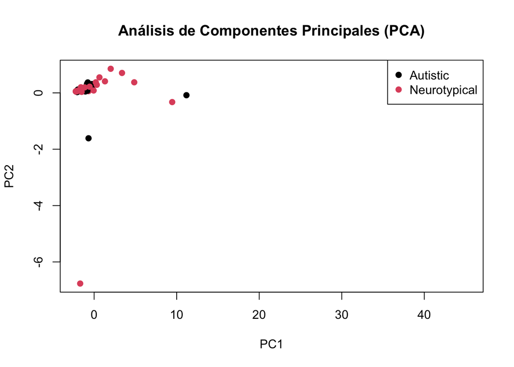

```r
pca_res <- prcomp(t(df_counts), scale. = TRUE)
plot(pca_res$x[, 1:2], col=as.factor(df_metadata$Study.Group), pch=19,
     xlab="PC1", ylab="PC2", main="Análisis de Componentes Principales (PCA)")
legend("topright", legend=levels(as.factor(df_metadata$Study.Group)), pch=19,
       col=1:length(levels(as.factor(df_metadata$Study.Group))))
```

Vemos que la distribución de los puntos es similar en las dos condiciones. Como este tipo de análisis en este caso no nos da mucha información, vamos a hacer un ggplot2 viendo la expresión de los metabolitos en los distintos grupos.

Se pone solo el código y se explica en el anexo.

```r
expr_data<- as.data.frame(assay(se))
expr_data$group <- df_metadata$Study.Group[match(rownames(se), df_metadata$Sample)]

expr_long <- expr_data %>%
  pivot_longer(cols = -group, names_to = "sample", values_to = "expression") %>%
  group_by(group, sample) %>%
  summarise(mean_expression = mean(expression, na.rm = TRUE))
```

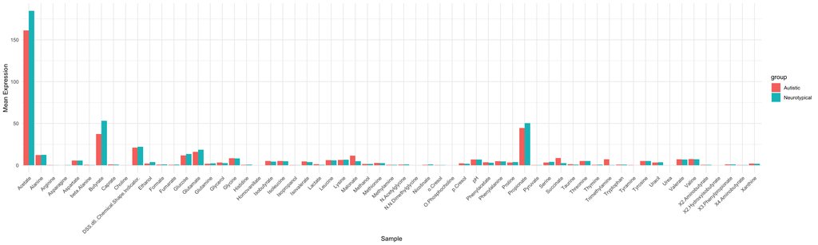

```r
expresion_grupos <- ggplot(expr_long, aes(x = sample, y = mean_expression, fill = group)) +
  geom_bar(stat = "identity", position = "dodge") +
  labs(x = "Sample", y = "Mean Expression") +
  theme_minimal() +
  theme(axis.text.x = element_text(angle = 45, hjust = 1))

expresion_grupos
```

Vemos que en general los metabolitos están igualmente presentes en los dos grupos. Se aprecia como en algunos la expresión es difernete, habría que hacer más análisis para ver si las diferencias son significativas.

Finalmente, hacemos un contenedor .Rda para almacenar nuestros datos.

```r
contenedor <- list(
  datos = df_counts,
  rowData = df_metadata,
  colData = df_coldata
)
save(contenedor, file = "contenedor_datos.Rda")
```

## 7 Subir los datos a GitHub

Para clonar los archivos de GitHub de mi repositorio, lo hago mediante Git. Creo un repositorio en el ordenador con el mismo nombre que el que tengo en GitHub. Una vez creados ambos repositorios, los sincronizo mediante el comando “git remote origin http://” donde el http debe ser en enlace a mi repositorio en GitHub. Luego con “push -u origin main” los clono, me pide el nombre de usuario y contraseña.

Una vez clonado el repositorio de GitHub en el ordenador, se van guardando los archivos generados y las distintas verisones. Para ello, como estoy usando RStudio, añado Commits a cada una de las versiones que quiero subir a GitHub, describiendo brevemente de que versión se va tratando. Una vez añadido el Commit, lo subo a GitHub mediante Push Branch.

## 8 Apèndice

Incluimos en este apéndice todo el código empleado para la PEC. Aunque ya se ha ido incluyendo en el informe, lo explicamos en este apartado. Lo primero que se hizo fue descargar los archivos del dataset escogido. Se descargaron directamente de GitHub y se cargaron en el repositorio. Una vez descargados, se cargan en RStudio.

```r
# Instalación de paquetes requeridos en el caso de no tenerlos instalado
if (!(require(BiocManager))) install.packages("BiocManager")
#Descargamos desde MiocManager el paquete SummarizedExperiment necesario para hacer el ejercicio
BiocManager::install("SummarizedExperiment")
#Cargamos la librería.
library(SummarizedExperiment)
#Aparte de SummarizedExperiment, vamos a necesitar un par de liberías más para poder hacer los ejercicios:
library(dplyr)
library(ggplot2)
library(tidyr)
```

```r
# Vamos a cargar el archivo que contiene los datos de medición de los diferentes metabolitos
df_counts <- read.csv(file="mtb.tsv", row.names = 1, head=TRUE, sep='\t')
# Cargamos el archivo que contiene la información de las filas, con información referente a cada paciente del estudio
df_metadata <- read.csv(file="metadata.tsv", head=TRUE, sep='\t')
# Cargamos ahora el archivo con la información de las columnas, los datos de cada metabolito
df_coldata <- read.csv(file='mtb.map.tsv', head=TRUE, sep='\t')

#Una vez cargados todos los datos, vamos a realizar el SummarizedExperiment. Es una función incluída en el paquete SummarizedExperiment que se descargó a través de Bioconductor. En esta función necesitamos varios datos:

# El assays: es el archivo que contiene los datos de estudio.
# rowData: contiene la información de las filas.
# ColData: Contiene la información para las columnas

#Generamos nuestro archivo:
se <- SummarizedExperiment(assays=df_counts, rowData=df_metadata, colData=df_coldata)
```

Una vez que hemos cargado nuestros archivos y construído el SummarizedExperiment, realizamos una exploración del dataset que nos permita saber qué es lo que tenemos:

```r
#Accederemos para empezar a las dimensiones de nuestro objeto:
dim(se)
#Lo priemro que haremos será tener una descripción genral de la estructura del objeto.
head(str(se))
# Obtenemos una visión general de las filas. La procedencia de los datos, si tiene autismo o no, la edad, sexo...
head(rowData(se))
#Hacemos lo mismo que con las filas, pero con las columnas. En este caso nos da información del HMDB (referencia en el Human Metabolome Database) y KEFF (a Database with molecules that are relevant to biological systems)
head(colData(se))

#Accedemos a los nombres de las columnas y nombres delas filas:
head(rownames(se))
head(colnames(se))
```

Incluímos aquí el código para el gráfico de las PCA y el ggplot2:

```r
#Hacémos un analisis de PCA con nuestro objeto
pca_res <- prcomp(t(df_counts), scale. = TRUE)
#Usamos la función básica plot de R para representarla, enfrentando en el eje X e Y los dos primeros componentes principales (los que explican la mayor parte de varianza) y agrupamos los datos (los coloreamos) según el grupo al que pertenecen
plot(pca_res$x[, 1:2], col=as.factor(df_metadata$Study.Group), pch=19,
     xlab="PC1", ylab="PC2", main="Análisis de Componentes Principales (PCA)")
legend("topright", legend=levels(as.factor(df_metadata$Study.Group)), pch=19,
       col=1:length(levels(as.factor(df_metadata$Study.Group))))
```

```r
# Para el ggplot, lo primero es convertir a dataframe los valores del objeto se
expr_data<- as.data.frame(assay(se))
#Una vez obtenido el dataframe, añadimos una columna 'grupo' que contendrá el grupo al que pertenecen los pacientes. Esta variable la obtendremos del dataframe df_metadata, que contiene la información sobre los apcientes (filas).
expr_data$group <- df_metadata$Study.Group[match(rownames(se), df_metadata$Sample)]
#Una vez creada, hacemos la media de los valores de cada metabolito para cada paciente y los agrupamos por grupo, de forma que para cada metabolito tendremos dos valores, la media de los niños con autismo y la media para los niños neurotípicos.
expr_long <- expr_data %>%
  pivot_longer(cols = -group, names_to = "sample", values_to = "expression") %>%
  group_by(group, sample) %>%
  summarise(mean_expression = mean(expression, na.rm = TRUE))

#Vamos ahora a realizar el ggplot. En el eje X pondremos los distintos metaabolitos y en el eje Y el valor de expresión. Cada grupo tiene un color diferente, de forma que se puedan ver las diferencias de expresión entre los dos grupos.
expresion_grupos <- ggplot(expr_long, aes(x = sample, y = mean_expression, fill = group)) +
  geom_bar(stat = "identity", position = "dodge") +  # Gráfica de barras para comparación
  labs(x = "Sample", y = "Mean Expression") +
  theme_minimal() +
  theme(axis.text.x = element_text(angle = 45, hjust = 1))  # Ajuste de texto
```

```r
#Código para crear el contenedor con nuestros datos.
#Hacemos una lista con los distintos dataframes, que será lo que luego exportaremos a .RData
contenedor <- list(
  datos = df_counts,
  rowData = df_metadata,
  colData = df_coldata
)
#Lo guardamos
save(contenedor, file = "contenedor_datos.Rda")
```

De esta manera, los datos quedan guardados en el contenedor y luego los podemos extraer directamente del archivo .RData

Introducimos aquí el código para clonar el repositorio GitHub.

```bash
#Entramos en la carpeta de nuestro repositorio en el ordeandor
cd Desktop/Quiros-Rodriguez-Isabel-PEC1
#Iniciamos Git
git init
#Nos conectameos con el repositorio creado en GitHub
git remote add origin https://github.com/IsabelQuiros/Quiros-Rodriguez-Isabel-PEC1.git
#Nos conectamos
git push origin main
#Nos va a pedir usuario y contraseña, los introducimos y ya nos podemos conectar.
```